# Lecture 12

Dealing with many zeros

Sara Martino

sara.martino@ntnu.no

Dept. of Mathematical Science, NTNU

Janine Illian

Janine.Illian@glasgow.ac.uk

University of Glasgow

Jafet Belmont

Jafet.Belmont@glasgow.ac.uk

University of Glasgow

## Motivation

- Count data are often modeled with **Poisson** or **Negative Binomial** models.
- These assume zeros occur naturally from the count process.
  - Example: for Poisson is $P(Y=0) = \exp(\lambda)$
- But in real data, we often see **too many zeros** → *zero inflation*.
- Examples:
  - Many people have **0 doctor visits** per year.
  - Most customers have **0 claims**.
  - Many species are **absent** from samples.

## Two main solutions

Both handle excess zeros but use **different assumptions** about how zeros are generated.

- **Zero-Inflated** Models
- **Hurdle** Models

## Two main solutions

Both handle excess zeros but use **different assumptions** about how zeros are generated.

- **Zero-Inflated** Models
  - Two sources of zero: inflation process or count process
- **Hurdle** Models

## Two main solutions

Both handle excess zeros but use **different assumptions** about how zeros are generated:

- **Zero-Inflated** Models
  - Two sources of zero: inflation process or count process
- **Hurdle** Models
  - Onle one source of zeros

## Zero-Inflated Models

Assume two processes:

- A binary process → decides if the observation is a certain zero.
- A count process → generates counts, *including* zeros.

$$\begin{aligned}
\text{P}(Y=0) & = \pi + (1-\pi)f(0) & \\
\text{P}(Y=y) & = (1-\pi)f(y)& y=1,2,\dots
\end{aligned}$$

**Note** In zero-inflated models $f(y)$ is typically discrete (ex Poisson, Binomial, …)

## Hurdle Models

Also have two parts, but different logic:

- A binary model determines if the observation crosses the hurdle (i.e. zero vs. positive).
- A **truncated** count model models only positive counts.

**Zeros come only from the first process**.

$$\begin{aligned}
\text{P}(Y=0) & = \pi & \\
\text{P}(Y=y) & = \frac{f(y)}{1-f(0)}& y=1,2,\dots
\end{aligned}$$

**Note** In hurdle models $f_Y(y)$ can also be continuous (f.ex Gamma). In these cases:
$$\begin{aligned}
\text{P}(Y=0) & = \pi & \\
f_Y(y) & = f(y)& y>0
\end{aligned}$$
where $f(y)$ is scaled so that it integrates to $1-\pi$

## Comparison: Zero-Inflated vs. Hurdle Models

| Feature | Zero-Inflated | Hurdle |
| --- | --- | --- |
| **Zeros come from** | Two sources (inflation + count) | One source (hurdle only) |
| **Positive part** | Includes zeros | Truncated at zero |
| **Can use continuous distributions?** | ❌ Typically count only | ✅ Yes (Gamma, Lognormal) |

## Zero Inflated models in `inlabru` (Type 1)

- Four zero-inflated models are implemented
  - Poisson (`zeroinflatedpoisson1`)
  - Binomial (`zeroinflatedbinomial1`)
  - Negative Binomial (`zeroinflatednbinomial1`)
  - BetaBinomial (`zeroinflatedbinomial1`)

To get details about the distributions you can type

```r
INLA::inla.doc("zero inflated")
```

The probability of the inflation process $\pi$ is a *hyperparameter* therefore cannot be modeled with covariates

## Example: number of fishes caught by fishermen at a state park.

```
  nofish persons child count
1      1       1     0     0
2      0       1     0     0
3      0       1     0     0
```

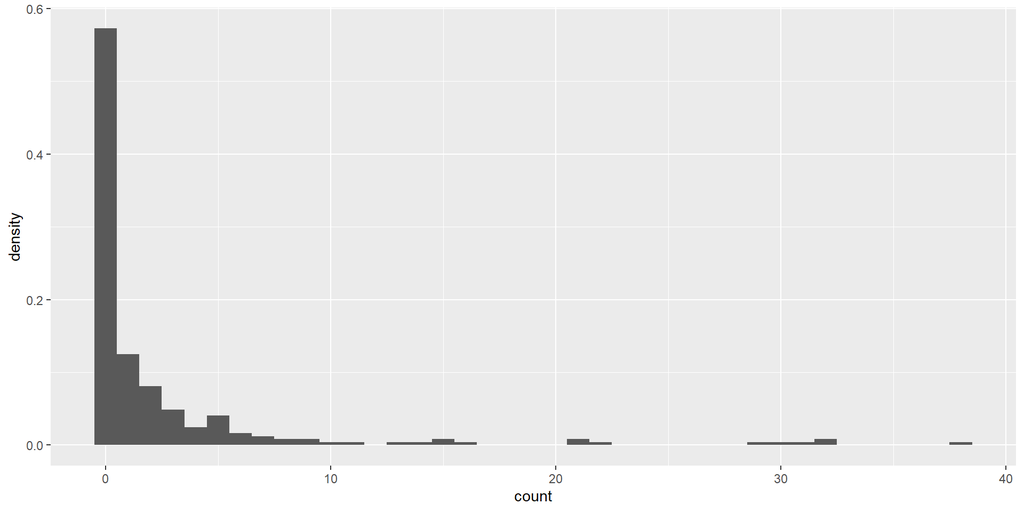

## Example: two models

$$\begin{eqnarray}
\text{Model 1: }\ & Y\sim \text{Poisson}(\lambda)\\
\text{Model 2: }\ & Y\sim \text{NegBinomial}(n,p)\\
\text{Linear predictor: }\ & \eta = \beta_0 + \beta_1x_1 + \beta_2x_2
\end{eqnarray}$$

## Example: two models

$$\begin{eqnarray}
\text{Model 1: }\ & Y\sim \text{Poisson}(\lambda)\\
\text{Model 2: }\ & Y\sim \text{NegBinomial}(n,p)\\
\text{Linear predictor: }\ & \eta = \beta_0 + \beta_1x_1 + \beta_2x_2
\end{eqnarray}$$

**Negative Binomial distribution**

$$\text{Prob}(Y=y) = \frac{\Gamma(y+n)}{\Gamma(n)\Gamma(y+1)}p^n(1-p)^y$$
with
$$E(Y) = \mu = n\frac{1-p}{p} \qquad \text{Var}(Y) = \mu(1+\frac{\mu}{n})$$
and linear predictor $\eta = log(\mu)$

## Example: Implementation

**The Model**
$$\begin{aligned}
\text{Model 1 }: y_i|\eta_i & \sim \pi1_{(y=0)} + (1-\pi)\text{Pois}(\lambda(\eta_i))\\
\text{Model 2 }: y_i|\eta_i & \sim \pi1_{(y=0)} + (1-\pi)\text{NegBin}(n(\eta_i),p(\eta_i))\\
\text{Linear Predictor }: \eta_i & = \color{red}{\boxed{\beta_0 + \beta_1 x_{1i} + \beta_2 x_{2i}}}
\end{aligned}$$

```r
zinb[1:3,]
```

```
  nofish persons child count
1      1       1     0     0
2      0       1     0     0
3      0       1     0     0
```

**The code**

```r
# define model components
cmp = ~ Intercept(1) + fishing(nofish, model = "linear") +
  persons(persons, model = "linear") +
  child(child, model = "linear")

# define model predictor
formula = count ~ .

# build the observation model
# Poisson model
lik_pois = bru_obs(formula,
                   family = "zeroinflatedpoisson1",
                   data = zinb)

# Negative binomial model
lik_nbin = bru_obs(formula,
                   family = "zeroinflatednbinomial1",
                   data = zinb)

# fit the model
fit_pois = bru(cmp, lik_pois)
fit_nbin = bru(cmp, lik_nbin)
```

## Example: Implementation

**The Model**
$$\begin{aligned}
\text{Model 1 }: \color{red}{\boxed{y_i|\eta_i}} & \color{red}{\boxed{\sim \pi1_{(y=0)} + (1-\pi)\text{Pois}(\lambda(\eta_i))}}\\
\text{Model 2 }: y_i|\eta_i & \sim \pi1_{(y=0)} + (1-\pi)\text{NegBin}(n(\eta_i),p(\eta_i))\\
\text{Linear Predictor }: \eta_i & = \beta_0 + \beta_1 x_{1i} + \beta_2 x_{2i}
\end{aligned}$$

```r
zinb[1:3,]
```

```
  nofish persons child count
1      1       1     0     0
2      0       1     0     0
3      0       1     0     0
```

**The code**

```r
# define model components
cmp = ~ Intercept(1) + fishing(nofish, model = "linear") +
  persons(persons, model = "linear") +
  child(child, model = "linear")

# define model predictor
formula = count ~ .

# build the observation model
# Poisson model
lik_pois = bru_obs(formula,
                   family = "zeroinflatedpoisson1",
                   data = zinb)

# Negative binomial model
lik_nbin = bru_obs(formula,
                   family = "zeroinflatednbinomial1",
                   data = zinb)

# fit the model
fit_pois = bru(cmp, lik_pois)
fit_nbin = bru(cmp, lik_nbin)
```

## Example: Implementation

**The Model**
$$\begin{aligned}
\text{Model 1 }: y_i|\eta_i & \sim \pi1_{(y=0)} + (1-\pi)\text{Pois}(\lambda(\eta_i))\\
\text{Model 2 }: \color{red}{\boxed{y_i|\eta_i}} & \color{red}{\boxed{\sim \pi1_{(y=0)} + (1-\pi)\text{NegBin}(n(\eta_i),p(\eta_i))}}\\
\text{Linear Predictor }: \eta_i & = \beta_0 + \beta_1 x_{1i} + \beta_2 x_{2i}
\end{aligned}$$

```r
zinb[1:3,]
```

```
  nofish persons child count
1      1       1     0     0
2      0       1     0     0
3      0       1     0     0
```

**The code**

```r
bru_options_set(control.compute = list(dic = T, waic = T, mlik = T))
# define model components
cmp = ~ Intercept(1) + fishing(nofish, model = "linear") +
  persons(persons, model = "linear") +
  child(child, model = "linear")

# define model predictor
formula = count ~ .

# build the observation model
# Poisson model
lik_pois = bru_obs(formula,
                   family = "zeroinflatedpoisson1",
                   data = zinb)

# Negative binomial model
lik_nbin = bru_obs(formula,
                   family = "zeroinflatednbinomial1",
                   data = zinb)

# fit the model
fit_pois = bru(cmp, lik_pois)
fit_nbin = bru(cmp, lik_nbin)
```

## Results - Fixed effects

```
[1] "Poisson Model"
```

```
           mean   sd 0.025quant 0.975quant
Intercept  0.22 0.15      -0.08       0.51
fishing   -0.90 0.12      -1.13      -0.67
persons    0.65 0.05       0.56       0.74
child     -0.95 0.10      -1.15      -0.76
```

```
[1] "Negative Binomial Model"
```

```
           mean   sd 0.025quant 0.975quant
Intercept -0.80 0.31      -1.42      -0.18
fishing   -0.59 0.25      -1.08      -0.10
persons    0.94 0.12       0.71       1.17
child     -1.65 0.19      -2.03      -1.27
```

## Results - Hyperparameters and scores

Hyperparameters

```
[1] "Poisson Model"
```

```
                                                       mean   sd
zero-probability parameter for zero-inflated poisson_1 0.48 0.04
```

```
[1] "Negative Binomial Model"
```

```
                                                         mean   sd
size for nbinomial_1 zero-inflated observations          0.56 0.10
zero-probability parameter for zero-inflated nbinomial_1 0.06 0.06
```

Scores

```
  Score Poisson    Nbin
1   DIC 1111.36  795.44
2  Mlik -579.97 -424.72
3  WAIC 1207.12  798.86
```

## Comparing estimated distribution for a specific data point

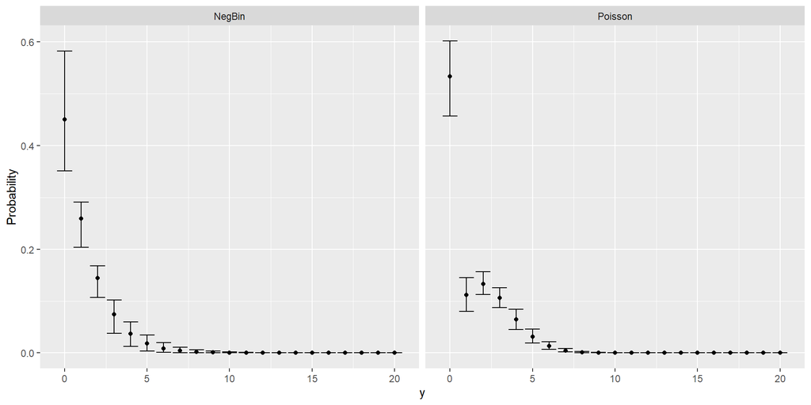

## Comparing estimated distribution - Implementation

```r
df_pred = data.frame(nofish = 0, persons = 1, child = 0)

prob_pois = predict(fit_pois, df_pred,
        formula = ~ {
          pi0 <- zero_probability_parameter_for_zero_inflated_poisson_1
          lambda = exp(Intercept +  fishing + persons + child)
          yy = 0:20
          list(
            prob0 =  pi0 * c(1,rep(0,20)) + (1-pi0) * dpois(yy, lambda = lambda))
          } )

prob_nbin = predict(fit_nbin, df_pred,
        formula = ~ {
          pi0 <- zero_probability_parameter_for_zero_inflated_nbinomial_1
          size = exp(size_for_nbinomial_1_zero_inflated_observations)
          mu = exp(Intercept +  fishing + persons + child)
          p = size/(size + mu)
          yy = 0:20
          list(prob0 = pi0 * c(1,rep(0,20)) + (1-pi0) * dnbinom(yy,size = size, mu = mu))
        })
```

## Comparing estimated distribution - Implementation

Note: To get the names to input in `predict` use the `bru_standardise_names()` function:

```r
inlabru::bru_standardise_names(fit_pois)
```

## Hurdle Models in `inlabru`

There are two ways to implement hurdle models in `inlabru`

- **Strategy 1** Use a modified version of the same distributions defined for the zero-inflated models
- **Strategy 2** Use a “two-likelihood” trick

## Strategy 1 - Implemented models

**Available models** (Type 0)

- Poisson (`zeroinflatedpoisson0`)
- Binomial (`zeroinflatedbinomial0`)
- Negative Binomial (`zeroinflatednbinomial0`)
- BetaBinomial (`zeroinflatedbinomial0`)

**Advantages**

- It works exactly as the zero-inflated models
- No need for extra coding

**Disadvantages**

- Can only be used for the models that are already implemented
- The probability of zero ($\pi$) is fixed and cannot have covariates

## Example Strategy 1: Implementation

**The Model**
$$\begin{aligned}
\text{Model 1 }: y_i|\eta_i & \sim \pi1_{(y=0)} + (1-\pi)\text{TruncPois}(\lambda(\eta_i))\\
\text{Model 2 }: y_i|\eta_i & \sim \pi1_{(y=0)} + (1-\pi)\text{TruncNegBin}(n(\eta_i),p(\eta_i))\\
\text{Linear Predictor }: \eta_i & = \beta_0 + \beta_1 x_{1i} + \beta_2 x_{2i}
\end{aligned}$$

```r
zinb[1:3,]
```

```
  nofish persons child count
1      1       1     0     0
2      0       1     0     0
3      0       1     0     0
```

**The code**

```r
# define model components
cmp = ~ Intercept(1) + fishing(nofish, model = "linear") +
  persons(persons, model = "linear") +
  child(child, model = "linear")

# define model predictor
formula = count ~ .

# build the observation model
# Poisson model
lik_pois = bru_obs(formula,
                   family = "zeroinflatedpoisson0",
                   data = zinb)

# Negative binomial model
lik_nbin = bru_obs(formula,
                   family = "zeroinflatednbinomial0",
                   data = zinb)

# fit the model
fit_pois0 = bru(cmp, lik_pois)
fit_nbin0 = bru(cmp, lik_nbin)
```

## Example Strategy 1: Results

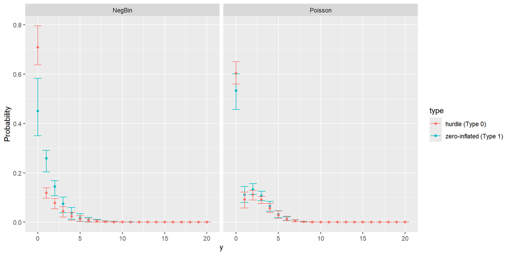

## Strategy 2 - Two-likelihood trick

**Advantages**

- More flexible model
- Can model also the probability of zero $\pi$
- Can also be used for continuous distributions with mass at 0

**Disadvantage**

- Some more coding

The Hurdle Model handles this by splitting the data-generating process into two parts:

1. **Zero-hurdle component**: This part is a binary model that estimates the probability of a zero count versus a non-zero count.
2. **Positive component**: This part models the distribution of the positive (non-zero) values.

This idea can be used in `inlabru` by using two likelihood

- A binomial likelihood to model the 0/1 process
- A continuous **positive** density or a **truncated** count distribution for the positive part

## Example - Gamma-Hurdle model

Daily precipitation in Parana state

$$z_{st} = \left\{
\begin{eqnarray}
0 & \text{ if } &\text{ no rain on day } t \text{ at station } s\\
1 & \text{ if } &\text{ rain on day } t \text{ at station } s
\end{eqnarray}
\right.$$

$$y_{st} = \left\{
\begin{eqnarray}
\text{NA} \text{ if } && \text{ no rain on day } t \text{ at station } s\\
\text{rain amout} \text{ if } && \text{ rain on day } t \text{ at station } s
\end{eqnarray}
\right.$$

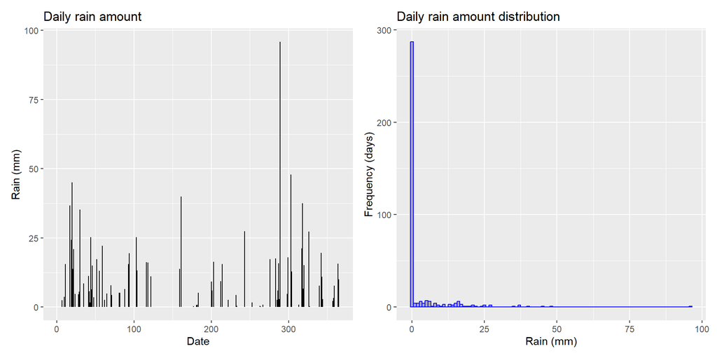

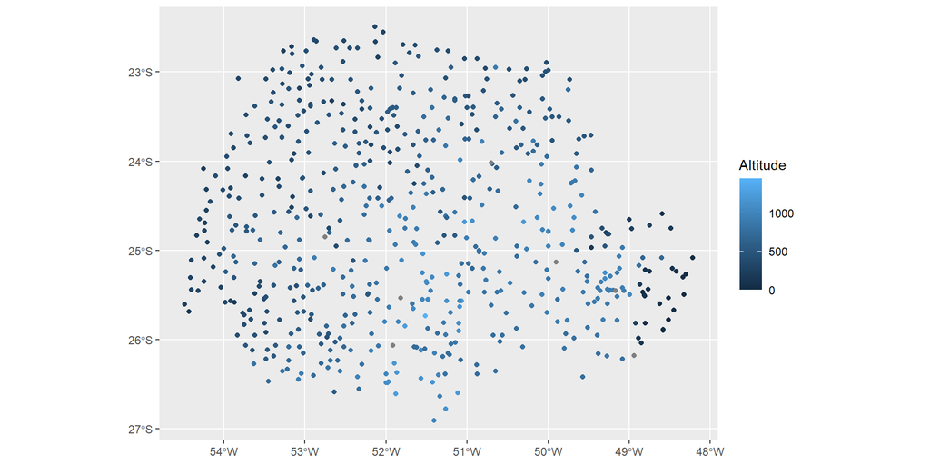

$$z_{st}\sim \text{Binom}(p_{st}, n_{st} = 1); \qquad y_{st}|z_{st}=1\sim\text{Gamma}(a,b) \ \text{with}\ E(y_{st}) = \mu_{st} = a/b$$
Where
$$\begin{eqnarray}
\eta_t^1 & = \text{logit}(p_t) & = \beta_0^B+u^B(s) \\
\eta_t^2 & = \log(\mu_t)& = \beta_0^G+u^G(s)
\end{eqnarray}$$

## Example - Gamma-Hurdle model

**Implementation**

1. Create response for binary and Gamma process

```r
df = df %>%
  mutate(z = ifelse(value==0,0,1),
         y = ifelse(value==0,NA, value),)
```

2. Define components, observation models and run

```r
cmp = ~ -1 + Intercept_z(1) + Intercept_y(1) +
  space_z(geometry, model = spde) +
  space_y(geometry, model = spde) +
  local_z(station, model = "iid")

lik_z = bru_obs(formula = z ~ Intercept_z + space_z + local_z,
                data = df %>% filter(time==1),
                family = "binomial")

lik_y = bru_obs(formula = y ~ Intercept_y + space_y,
                data =  df %>% filter(time==1),
                family = "gamma")

fit = bru(cmp, lik_z, lik_y)
```

## Example - Gamma-Hurdle model

**Results**

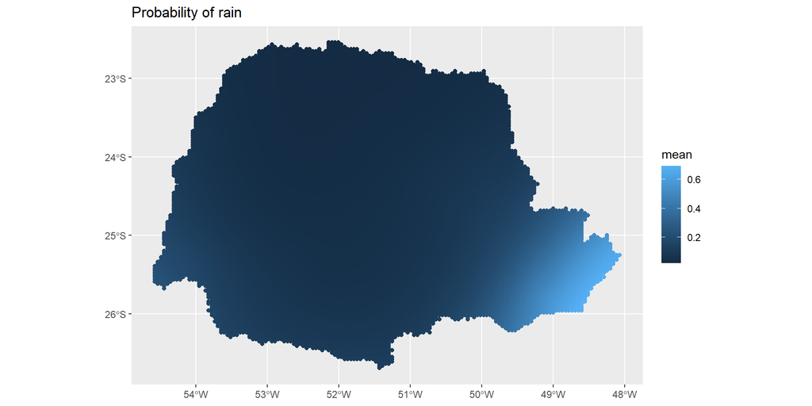

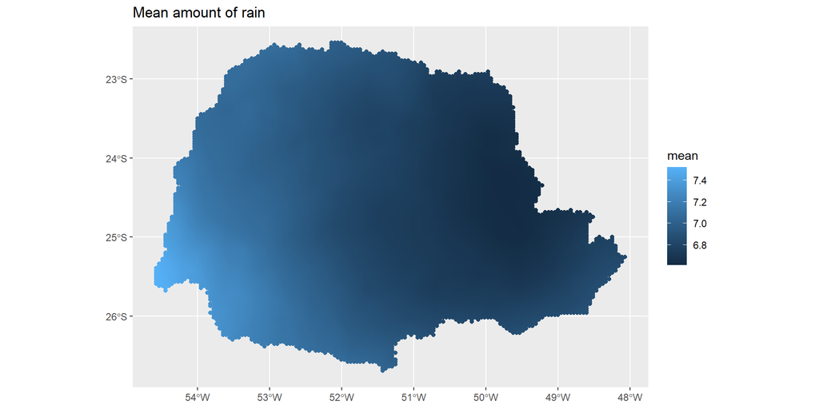

## Example - Gamma-Hurdle model

We can:

- use other components in both linear predictors $\eta^1$ and $\eta^2$
- have shared components between the two linear predictor
- use other positive-continuous distribution instead of the Gamma (for example log-Normal, Weibull, etc.)

## Example - Poisson- Hurdle model

Let’s look again at the fishes examples. We now want to include covariates also in the model for the zero probability:

$$\begin{eqnarray}
P(Y = 0) = &\pi\\
P(Y=y) = & (1-\pi) \frac{f_Y(y)}{f_Y(0)},& \qquad y =1,2,\dots
\end{eqnarray}$$
We use the same “trick” as before and we now have
$$\begin{eqnarray}
z\sim\text{Binomial}(\pi,n); &\qquad \eta_1 = \text{logit}(\pi) = \beta^1X\\
z\sim\text{Truncated Poisson}(\lambda); &\qquad \eta_2 =\log(\lambda) = \beta^2X\\
\end{eqnarray}$$
In `inlabru` the **truncated Poisson distribution** is called `nzpoisson`

## Example - Poisson- Hurdle model

**Implementation**

1. Define response for binary and truncated poisson process

```r
zinb  = zinb %>%
  mutate(z = ifelse(count==0,1,0),
         y = ifelse(count==0,NA, count))
```

2. Define components, observation models and run

```r
cmp = ~ -1 + Intercept_z(1) + Intercept_y(1) +
  nofish_z(nofish, model = "linear") + persons_z(persons, model = "linear") +
    nofish_y(nofish, model = "linear") + persons_y(persons, model = "linear")

lik_z = bru_obs(formula = z~ Intercept_z  + nofish_z + persons_z,
                data = zinb,
                family = "binomial")

lik_y = bru_obs(formula = y~ Intercept_y  + nofish_y + persons_y,
                data = zinb,
                family = "nzpoisson")

fit = bru(cmp, lik_z, lik_y)
```

## Example - Poisson- Hurdle model

**Results**

```r
round(fit$summary.fixed,2)
```

```
             mean   sd 0.025quant 0.5quant 0.975quant  mode kld
Intercept_z  0.70 0.33       0.04     0.70       1.35  0.70   0
nofish_z     0.23 0.28      -0.33     0.23       0.78  0.23   0
persons_z   -0.18 0.12      -0.41    -0.18       0.04 -0.18   0
Intercept_y  0.35 0.15       0.05     0.35       0.65  0.35   0
nofish_y    -0.83 0.12      -1.07    -0.83      -0.59 -0.83   0
persons_y    0.53 0.04       0.44     0.53       0.61  0.53   0
```

- In `inlabru` there is no implementation for the *truncated binomial* (or negative binomial) distribution
- We can “trick” `inlabru` by using one of the implemented **Type 0** models
  $$y_i|\eta_i \sim \pi1_{(y=0)} + (1-\pi)\frac{f(y)}{f(0)}$$
  with a *fixed* and small $\pi$ thus creating a *truncated* distribution!

**Implementation**

1. Define response and the components

```r
# Define response for binary and truncated neg. binomial
zinb  = zinb %>% mutate(z = ifelse(count==0,1,0),
                        y = ifelse(count==0,NA, count))
# define model components
cmp = ~ -1 + Intercept_z(1) + Intercept_y(1) +
  fishing_z(nofish, model = "linear") + fishing_y(nofish, model = "linear") +
  persons_z(persons, model = "linear") + persons_y(persons, model = "linear") +
  child_z(child, model = "linear") + child_y(child, model = "linear")
```

2. Build the likelihood for the binomial part

```r
# build the observation model
# Poisson model
lik_binom = bru_obs(z ~ Intercept_z + fishing_z + persons_z + child_z ,
                   family = "binomial",
                   data = zinb)
```

3. Define the type 0 Negbinomial with $\pi$ fixed to a small value

```r
# Negative binomial model
lik_trunc_nbin = bru_obs(y ~ Intercept_y + fishing_y + persons_y + child_y ,
                   family = "zeroinflatednbinomial0",
                   data = zinb,
                   control.family = list(hyper = list(theta = list(initial = -20,
                                                                   fixed = TRUE))))
```

4. Run the model

```r
fit_nbin = bru(cmp, lik_binom, lik_trunc_nbin)
```

## Summary - Treating many zero with `inlabru`

There are mainly two types of models to treat excess of zeros

- Zero inflated models
- Hurdle models

## Summary - Treating many zero with `inlabru`

There are mainly two types of models to treat excess of zeros

- Zero inflated models
  - Zeros come from two sources
  - Can only be used for counts (Poisson, Binomial,…)
  - Four likelihood are implemented in `inlabru` (Type1)
  - The probability of zero-inflation is **constant**
- Hurdle models

## Summary - Treating many zero with `inlabru`

There are mainly two types of models to treat excess of zeros

- Zero inflated models
- Hurdle models
  - Only one source of zeros
  - Positive values can be both discrete and continuous
  - Two ways to imlement in `inlabru`

## Summary - Treating many zero with `inlabru`

There are mainly two types of models to treat excess of zeros

- Zero inflated models
- Hurdle models
  - Only one source of zeros
  - Positive values can be both discrete and continuous
  - Two ways to imlement in `inlabru`
    1. Use the implemented Type0 likelihoods
    - Probability of zero is constant
    2. Use the “two-likelihood” approach
    - Probability of zero can be modelled